# Figures

Shreya D.

2026-07-07

# FIGURES

## Visualising location and bird species

For visualising purposes we use adapt code by [Mentesana, Hau, D’Amelio, Adreani, & Sánchez-Tójar, (2025)](https://doi.org/10.1111/ele.70100), available on the accompanying [GitHub repository](https://github.com/ASanchez-Tojar/meta-analysis_egg_hormones_and_fitness/blob/main/code/003_figures.R).

The following code chunk is used to set up the workspace and load (or install) all required packages to replicate the generatation of figures and tables presented in our manuscript.

```r
## Setting up workspace using pacman
if (!requireNamespace("pacman", quietly = TRUE)) {
  install.packages("pacman")
}

## installing orchaRd from GitHub
if (!requireNamespace("orchaRd", quietly = TRUE)) {
  ## installing orchaRd from GitHub
  pacman::p_install_gh("daniel1noble/orchaRd", ref = 'main')
}

## Install/load required packages
pacman::p_load(
  cowplot,
  ggraph, # visualising author network
  gt, # suppl
  here,
  igraph, # visualising author network
  maps,
  metafor,
  orchaRd,
  patchwork,
  purrr,
  tidyverse)
```

For the purpose of this map, longitude and latitude of the study area manually added to the dataset. They are saved to `dataset_analysis$population_location` as they were extracted from the respective papers. If not provided by the authors, a general location was manually selected. Note, coordinates are used for visualising only.

- Load datasets

```r
## Load data for plotting a location map
## -----------------------------------------------------------

# Loading cleaned dataset
dataset_analysis <- read_csv(here::here("data/04_data_analysis/dataset_analysis.csv"))
## Split population_ID into location and country
dataset_analysis[c('Location','Country')] <- str_split_fixed(dataset_analysis$population_ID, ',', 2)

## set coordinates for sampling locations
data_coordinates <- data.frame(
  Location = unique(dataset_analysis$Location),
  Lat_Location = c(51.50, 38.41, 40.45, 45.40, 52.39, 37.18,
                   40.53, 54, 39.05, 51.57, 48, 42.54, 39.95,
                   40.13,28.10,52.06,60.39),
  Long_Location = c(19.29,-9.02,-3.50, -64.10, 6.05, -3.11,
                    -4.01, -124, -76.81, -2.26, 11, 8.91,
                    -75.16, -8.27, 107.10, 8.25, 5.32))

## Let's now merge the datasets by the location names
dataset_analysis <- dataset_analysis %>%
  left_join(data_coordinates, by = "Location")

## Count how many times each Location appears in the full dataset
location_counts <- dataset_analysis %>%
  group_by(Location, bird_species) %>%
  summarise(size.freq = n())
```

```
## `summarise()` has regrouped the output.
## ℹ Summaries were computed grouped by Location and bird_species.
## ℹ Output is grouped by Location.
## ℹ Use `summarise(.groups = "drop_last")` to silence this message.
## ℹ Use `summarise(.by = c(Location, bird_species))` for per-operation grouping
##   (`?dplyr::dplyr_by`) instead.
```

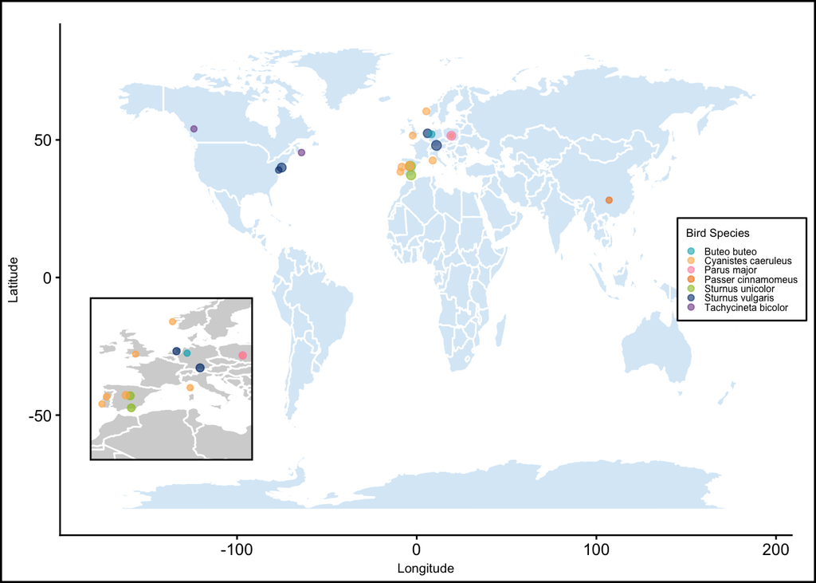

```r
# I will subset the data base so that I get one row per Location AND bird_species.
# Like this, I get one point per location independently of the number of effect sizes
# we have per place.
dataset_analysis_unique_rows <- dataset_analysis %>%
  distinct(Location, bird_species, .keep_all = TRUE)

# Merge the counts into the unique rows dataset
dataset_analysis_unique_rows <- dataset_analysis_unique_rows %>%
  left_join(location_counts, by = c("Location", "bird_species"))

# create data for world coordinates using
# map_data() function
world_coordinates <- map_data("world")

# create world map using ggplot() function
# geom_map() function takes world coordinates as input to plot world map
fig_map <- ggplot(world_coordinates, aes(x = long, y = lat)) +
  geom_map(map = world_coordinates,
           aes(map_id = region),
           color = "white", fill = "#D9EAF7") +
  geom_point(data = dataset_analysis_unique_rows,
             aes(x = Long_Location, y = Lat_Location,
                 size = size.freq, colour = bird_species),
             alpha = 0.6) +
  scale_size(range = c(1, 2.5)) +
  scale_fill_manual(values = c("#00B0BE","#FFB255",  "#FF8CAE",
                               "#F47A00", "#98C127","#003A7D","#7E4794")) +

  scale_colour_manual(values = c("#00B0BE","#FFB255",  "#FF8CAE",
                                 "#F47A00", "#98C127","#003A7D","#7E4794")) +
  guides(size = "none", alpha = "none",
         colour = guide_legend(override.aes = list(size = 1.5), keywidth = 0.4,
                               keyheight = 0.4)) +
  labs(x = "Longitude",
       y = "Latitude",
       col = "Bird Species") +
  theme_classic() +
  theme(plot.margin = margin(t = 15, r = 15, b = 5, l = 5),
        legend.position = c(1.02, 0.42),
        legend.justification = c("right", "bottom"),
        legend.background = element_rect(fill = "white", color = "black"),
        legend.text = element_text(size = 6),
        legend.title = element_text(size = 7),
        axis.title = element_text(size = 8),
        axis.text.x = element_text(size = 10),
        axis.text.y = element_text(size = 10))

# To add the zoomed in map.. to show the points more clearly
zoom_map <- ggplot() +
  geom_map(data = world_coordinates, map = world_coordinates,
           aes(map_id = region),
           color = "white", fill = "#D4D4D4") +
  geom_point(data = dataset_analysis_unique_rows,
             aes(x = Long_Location, y = Lat_Location,
                 size = size.freq, colour = bird_species),
             position = position_jitter(width = 0.2, height = 0.2),
             alpha = 0.7) +
  scale_size(range = c(1, 2)) +
  scale_colour_manual(values = c("#00B0BE","#FFB255",  "#FF8CAE",
                                 "#F47A00", "#98C127","#003A7D","#7E4794")) +
  coord_cartesian(xlim = c(-10, 20), ylim = c(25, 65)) +  # Northern Hemisphere
  theme_void() +
  theme(legend.position = "none",
        plot.background = element_rect(color = "white", fill = "white"),
        panel.border = element_rect(colour = "black", fill = NA, size = 1))
geographic_distribution <- ggdraw() +
  draw_plot(fig_map) +
  draw_plot(zoom_map, x = 0.11, y = 0.21, width = 0.20, height = 0.28) +
  theme(panel.border = element_rect(colour = "black", fill = NA, size = 1.2))

print(geographic_distribution)
```

```r
## Save image file
ggsave(here::here("figures/Figure_Distribution.png"),
       plot = geographic_distribution, height = 100, width = 170, units= 'mm', dpi = 600)
```

## Visualizing author network

```r
# Sun Aug 31 19:25:52 2025 ------------------------------
# Show code, but eval = FALSE

## Loading cleaned dataset
# Sun Aug 31 19:26:35 2025 ------------------------------
# The folliwing file is not found, assume same as above?!
# dataset_analysis<- read_csv(here::here("data/03_data_cleaning/dataset_analysis.csv"))

clean_author <- function(name) {
  name %>%
    str_replace_all(",", "") %>%   # remove commas
    str_squish() %>%              # remove excess whitespace
    str_to_title()                # standardize case (optional, if needed)
}

# Apply cleaning to first and last author fields
author_roles <- dataset_analysis %>%
  distinct(paper_ID, .keep_all = TRUE) %>%
  select(paper_ID, authors, bird_species) %>%
  mutate(
    author_list = str_split(authors, ";\\s*"),
    first_author = map_chr(author_list, 1),
    last_author = map_chr(author_list, ~ tail(.x, 1))
  ) %>%
  mutate(
    first_author=case_when(
      first_author == "Polo, V" | first_author == "Polo V" ~ "Polo V.",
      first_author == "Soler J J" ~ "Soler J. J.",
      first_author == "Glądalski, M" ~ "Gladalski M.",
      first_author == "Gwinner, H" | first_author == "Gwinner H" ~ "Gwinner H.",
      TRUE ~ as.character(first_author)
    )) %>%
  mutate(
    last_author=case_when(
      last_author == "Veiga J P" ~ "Veiga J. P.",
      TRUE ~ as.character(last_author)
    )
  )

# 2. Create Core Author Pairs (First → Last)
author_pairs_core <- author_roles %>%
  select(paper_ID, first_author, last_author) %>%
  rename(from = first_author, to = last_author) %>%
  filter(from != to) %>%
  count(from, to, name = "weight")

# 3. Build Author Graph
author_graph <- graph_from_data_frame(author_pairs_core, directed = TRUE)

# 4. Assign Dominant Bird Species to PIs (last authors)
author_species <- author_roles %>%
  select(last_author, bird_species) %>%
  group_by(last_author, bird_species) %>%
  count() %>%
  slice_max(n, n = 1) %>%
  distinct(last_author, .keep_all = TRUE)

# Add species as vertex attribute
V(author_graph)$bird_species <- author_species$bird_species[
  match(V(author_graph)$name, author_species$last_author)
]

# 5. Optional: Scale node size by number of papers per author
author_paper_counts <- author_roles %>%
  pivot_longer(cols = c(first_author, last_author), names_to = "role", values_to = "author") %>%
  count(author, name = "paper_count")

# Add paper count attribute
V(author_graph)$paper_count <- author_paper_counts$paper_count[
  match(V(author_graph)$name, author_paper_counts$author)
]

# Replace NAs with small size for isolated authors
V(author_graph)$paper_count[is.na(V(author_graph)$paper_count)] <- 1

# 6. Plot with ggraph
ggraph(author_graph, layout = "fr") +
  geom_edge_link(aes(width = weight), alpha = 0.4, color = "grey50") +
  geom_node_point(aes(color = bird_species, size = paper_count)) +
  geom_node_text(aes(label = name), repel = TRUE, size = 3) +
  scale_edge_width(range = c(0.3, 2)) +
  scale_size(range = c(3, 10)) +
  theme_void() +
  labs(title = "Author Collaboration Network by Bird Species",
       size = "Paper Count") +
  theme(legend.position = "right")
```

## Intercept only model

Orchard plot for overall effect of green nest material on fitness using lnRR and SMDH

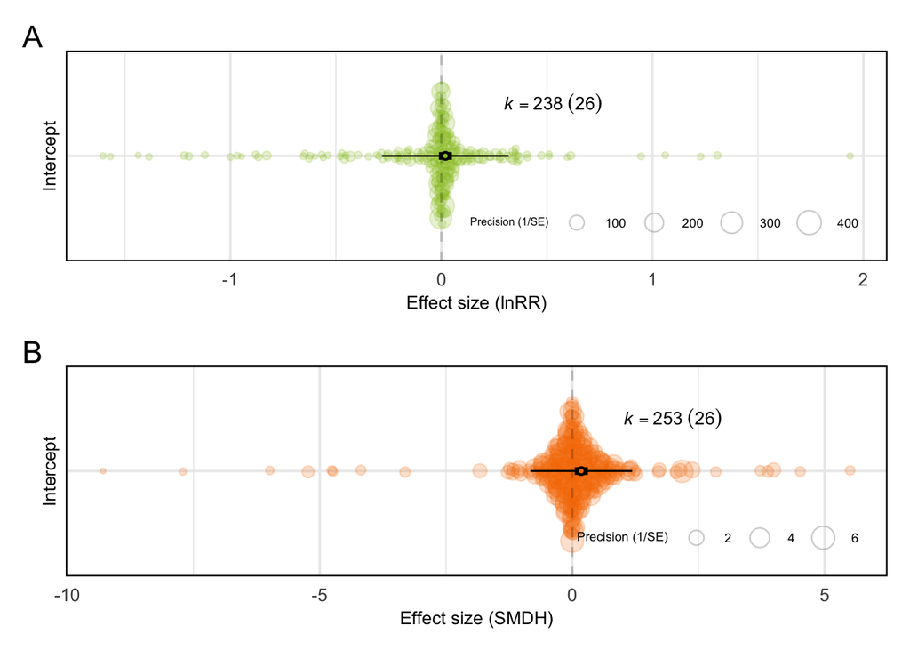

```r
# Loading models for SMDH and lnRR
intercept_lnRR <- readRDS(here::here("model/intercept_lnRR.rds"))
intercept_SMDH <- readRDS(here::here("model/intercept_SMDH.rds"))

# Plot for lnRR
intercept_lnRR_plot <- orchaRd::orchard_plot(
  intercept_lnRR,
  mod = "1",
  group = "paper_ID",
  trunk.size = 0.3,
  branch.size = 2,
  twig.size = 0.5,
  alpha = 0.2,
  xlab = "Effect size (lnRR)",
  fill =  T,
  k.pos = c(0.53,0.6,0.6)) +
  scale_fill_manual(values = "#98C127") +
  scale_colour_manual(values = "#98C127" ) +
  theme_minimal(base_size = 14) +
  theme(
    panel.border = element_rect(colour = "black", fill = NA, size = 0.8),
    legend.position = c(0.98, 0.05),
    legend.justification = c(1, 0),
    legend.direction = "horizontal",
    legend.title = element_text(size = 6),
    legend.text = element_text(size = 7),
    axis.title = element_text(size = 10),
    axis.text.x = element_text(size = 10),
    axis.text.y = element_blank()) +
  labs(x = "Intercept")
# Plot for SMDH
intercept_SMDH_plot <- orchaRd::orchard_plot(
  intercept_SMDH,
  mod = "1",
  group = "paper_ID",
  trunk.size = 0.3,
  branch.size = 2,
  twig.size = 0.5,
  alpha = 0.2,
  xlab = "Effect size (SMDH)",
  fill = TRUE,
  k.pos = c(2,0.6,0.6)) +
  scale_fill_manual(values = "#F47A00") +
  scale_colour_manual(values = "#F47A00") +
  theme_minimal(base_size = 14) +
  theme(
    panel.border = element_rect(colour = "black", fill = NA, size = 0.8),
    legend.position = c(0.98, 0.05),
    legend.justification = c(1, 0),
    legend.direction = "horizontal",
    legend.title = element_text(size = 7),
    legend.text = element_text(size = 7),
    axis.title = element_text(size = 10),
    axis.text.x = element_text(size = 10),
    axis.text.y = element_blank()
  ) +
  labs(x = "Intercept")
# Combine using patchwork
Figure_intercept <- intercept_lnRR_plot / intercept_SMDH_plot +
  plot_annotation(tag_level = c("A","B"))
print(Figure_intercept)
```

```r
## save image file
ggsave(here::here("figures/Figure_overall_effect.png"),
       plot = Figure_intercept, height = 150, width = 170, units = "mm", dpi = 600)
```

Now the crop the figure as presented in the main manuscript

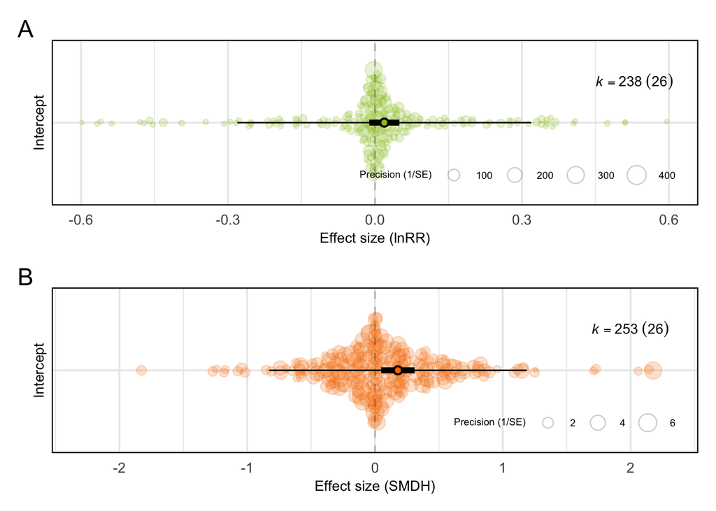

```r
intercept_lnRR_plot_crop <- orchaRd::orchard_plot(
  intercept_lnRR,
  mod = "1",
  group = "paper_ID",
  trunk.size = 0.5,
  branch.size = 2,
  twig.size = 0.5,
  alpha = 0.2,
  xlab = "Effect size (lnRR)",
  fill =  T,
  k.pos = c(0.53,0.6,0.6)) +
  scale_fill_manual(values = "#98C127") +
  scale_colour_manual(values = "#98C127" ) +
  scale_y_continuous(limits = c(-0.6, 0.6)) +
  theme_minimal(base_size = 14) +
  theme(
    panel.border = element_rect(colour = "black", fill = NA, size = 0.8),
    legend.position = c(0.98, 0.05),
    legend.justification = c(1, 0),
    legend.direction = "horizontal",
    legend.title = element_text(size = 7),
    legend.text = element_text(size = 7),
    axis.title = element_text(size = 10),
    axis.text.x = element_text(size = 10),
    axis.text.y = element_blank()) +
  labs(x = "Intercept")
# Plot for SMDH
intercept_SMDH_plot_crop <- orchaRd::orchard_plot(
  intercept_SMDH,
  mod = "1",
  group = "paper_ID",
  trunk.size = 0.5,
  branch.size = 2,
  twig.size = 0.5,
  alpha = 0.2,
  xlab = "Effect size (SMDH)",
  fill = TRUE,
  k.pos = c(2,0.6,0.6)) +
  scale_fill_manual(values = "#F47A00") +
  scale_colour_manual(values = "#F47A00") +
  scale_y_continuous(limits = c(-2.3, 2.3)) +
  theme_minimal(base_size = 14) +
  theme(
    panel.border = element_rect(colour = "black", fill = NA, size = 0.8),
    legend.position = c(0.98, 0.05),
    legend.justification = c(1, 0),
    legend.direction = "horizontal",
    legend.title = element_text(size = 7),
    legend.text = element_text(size = 7),
    axis.title = element_text(size = 10),
    axis.text.x = element_text(size = 10),
    axis.text.y = element_blank()) + labs(x = "Intercept")
# Combine using patchwork
Figure_intercept_crop <- intercept_lnRR_plot_crop / intercept_SMDH_plot_crop +
  plot_annotation(tag_level = c("A","B"))
print(Figure_intercept_crop)
```

```r
## save image file
ggsave(here::here("figures/Figure_overall_effect_crop.png"),
       plot = Figure_intercept_crop, height = 150, width = 170, units = "mm", dpi = 600)
```

## Hypothesis meta-regression

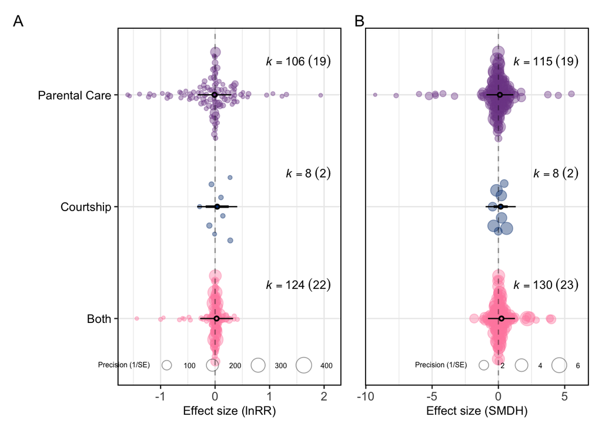

```r
# Loading models for SMDH and lnRR
lnRR_hypothesis <- readRDS(here::here("model/lnRR_hypothesis.rds"))
SMDH_hypothesis <- readRDS(here::here("model/SMDH_hypothesis.rds"))

# Plot lnRR meta-regression on hypothesis
lnRR_hypothesis_plot <- orchard_plot(mod_results(
  lnRR_hypothesis,
  mod = "Hypothesis",
  group = "paper_ID"),
  trunk.size = 0.25,
  branch.size = 1,
  twig.size = 0.5,
  alpha = 0.4,
  xlab = "") +
  scale_colour_manual(values = c("#FF8CAE", "#003A7D", "#7E4794")) +
  scale_fill_manual(values = c("#FF8CAE", "#003A7D", "#7E4794")) +
  labs(x = "",
       y = "Effect size (lnRR)") +
  theme(
    panel.border = element_rect(colour = "black", fill = NA, linewidth = 0.8),
    legend.position.inside = c(0.99, 0.01),
    legend.background = element_blank(),
    legend.key = element_blank(),
    legend.justification = c(1, 0),
    legend.direction = "horizontal",
    legend.title = element_text(size = 6),
    legend.text = element_text(size = 6),
    axis.title = element_text(size = 10),
    axis.text.x = element_text(size = 10),
    axis.text.y = element_text(angle = 0, vjust = 0.5, hjust = 1)) +
  scale_x_discrete(labels = c("Both","Courtship","Parental Care"))
# Plot SMDH meta-regression on hypothesis
SMDH_hypothesis_plot <- orchard_plot(mod_results(
  SMDH_hypothesis,
  mod = "Hypothesis",
  group = "paper_ID"),
  trunk.size = 0.25,
  branch.size = 1,
  twig.size = 0.5,
  alpha = 0.4,
  xlab = "") +
  scale_colour_manual(values = c("#FF8CAE", "#003A7D", "#7E4794")) +
  scale_fill_manual(values = c("#FF8CAE", "#003A7D", "#7E4794")) +
  labs(x = "", y = "Effect size (SMDH)") +
  theme(
    panel.border = element_rect(colour = "black", fill = NA, linewidth = 0.8),
    legend.position.inside = c(0.99, 0.01),
    legend.background = element_blank(),
    legend.key = element_blank(),
    legend.justification = c(1, 0),
    legend.direction = "horizontal",
    legend.title = element_text(size = 6),
    legend.text = element_text(size = 6),
    axis.title = element_text(size = 10),
    axis.text.x = element_text(size = 10),
    axis.text.y = element_text(angle = 0, vjust = 0.5, hjust = 1)) +
  scale_x_discrete(labels = c("Both","Courtship","Parental Care"))
SMDH_hypothesis_plot <- SMDH_hypothesis_plot +
  theme(axis.text.y  = element_blank(),
        axis.title.y = element_blank(),
        axis.ticks.y = element_blank())

# Combine using patchwork
Figure_hypothesis <- lnRR_hypothesis_plot + SMDH_hypothesis_plot +
  plot_annotation(tag_level = c("A","B"))
print(Figure_hypothesis)
```

```r
## save image file
ggsave(here::here("figures/Figure_hypothesis.png"),
       plot = Figure_hypothesis, height = 120, width = 250, units = "mm", dpi = 600)
```

Now the cropped figures for the main manuscript

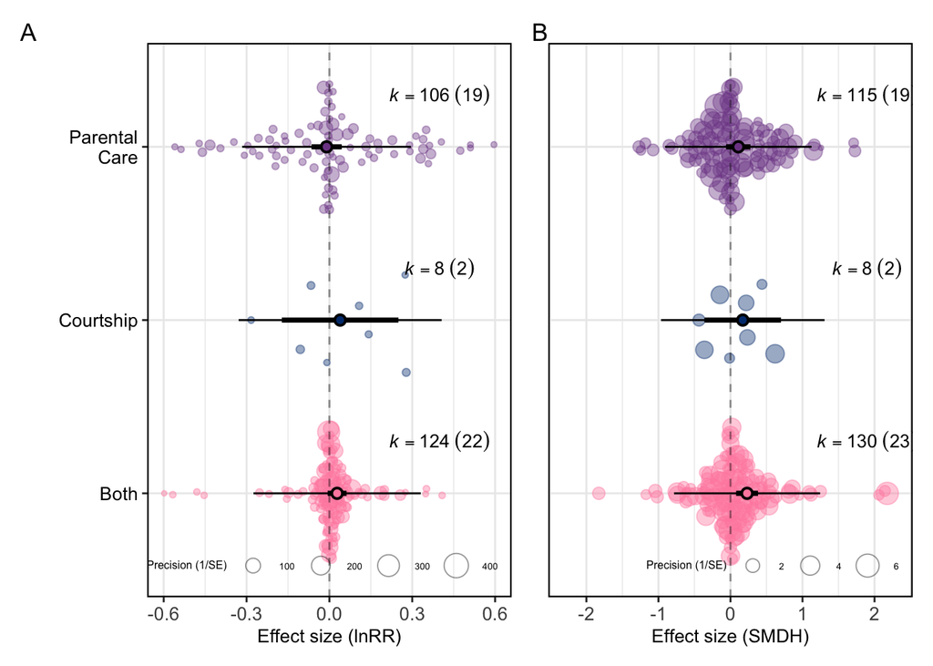

```r
# Plot lnRR meta-regression on hypothesis
lnRR_hypothesis_plot_crop <- orchard_plot(mod_results(
  lnRR_hypothesis,
  mod = "Hypothesis",
  group = "paper_ID"),
  trunk.size = 0.5,
  branch.size = 1.3,
  twig.size = 0.5,
  alpha = 0.4,
  fill = T,
  k.pos = c(0.4,0.6,0.6),
  xlab = "") +
  scale_colour_manual(values = c("#FF8CAE", "#003A7D", "#7E4794")) +
  scale_fill_manual(values = c("#FF8CAE", "#003A7D", "#7E4794")) +
  scale_y_continuous(limits = c(-0.6, 0.6)) +
  labs(x = "",
       y = "Effect size (lnRR)") +
  theme(panel.border = element_rect(colour = "black", fill = NA, linewidth = 0.8),
        legend.position.inside = c(0.99, 0.01),
        legend.justification = c(1, 0),
        legend.direction = "horizontal",
        legend.background = element_blank(),
        legend.key = element_blank(),
        legend.title = element_text(size = 6),
        legend.text = element_text(size = 5),
        axis.title = element_text(size = 10),
        axis.text.x = element_text(size = 10),
        axis.text.y = element_text(angle = 0, vjust = 0.5, hjust = 1)) +
  scale_x_discrete(labels = c("Both","Courtship","Parental\nCare"))
# Plot SMDH meta-regression on hypothesis
SMDH_hypothesis_plot_crop <- orchard_plot(mod_results(
  SMDH_hypothesis,
  mod = "Hypothesis",
  group = "paper_ID"),
  trunk.size = 0.5,
  branch.size = 1.3,
  twig.size = 0.5,
  alpha = 0.4,
  fill = T,
  k.pos = c(1.9,0.6,0.6),
  xlab = "") +
  scale_colour_manual(values = c("#FF8CAE", "#003A7D", "#7E4794")) +
  scale_fill_manual(values = c("#FF8CAE", "#003A7D", "#7E4794")) +
  scale_y_continuous(limits = c(-2.3, 2.3)) +
  labs(x = "",
       y = "Effect size (SMDH)") +
  theme(panel.border = element_rect(colour = "black", fill = NA, linewidth = 0.8),
        legend.position.inside = c(0.99, 0.01),
        legend.justification = c(1, 0),
        legend.direction = "horizontal",
        legend.background = element_blank(),
        legend.key = element_blank(),
        legend.title = element_text(size = 6),
        legend.text = element_text(size = 5),
        axis.title = element_text(size = 10),
        axis.text.x = element_text(size = 10),
        axis.text.y = element_text(angle = 0, vjust = 0.5, hjust = 1)) +
  scale_x_discrete(labels = c("Both","Courtship","Parental\nCare"))
SMDH_hypothesis_plot_crop <- SMDH_hypothesis_plot_crop +
  theme(axis.text.y  = element_blank(),
        axis.title.y = element_blank(),
        axis.ticks.y = element_blank())

# Combine using patchwork
Figure_hypothesis_crop <- lnRR_hypothesis_plot_crop + SMDH_hypothesis_plot_crop +
  plot_annotation(tag_level = c("A","B"))
print(Figure_hypothesis_crop)
```

```r
ggsave(here::here("figures/Figure_hypothesis_crop.png"),
       plot = Figure_hypothesis_crop, height = 120, width = 250, units = "mm", dpi = 600)
```

## Other meta-regressions

### A. Combined Plot

#### Time of green nest material addition

```r
# Loading models for SMDH and lnRR

lnRR_time_gnm_addition <- readRDS(here::here("model/lnRR_time_gnm_addition.rds"))
SMDH_time_gnm_addition <- readRDS(here::here("model/SMDH_time_gnm_addition.rds"))

lnRR_time_gnm_addition_plot <- orchard_plot(mod_results(
  lnRR_time_gnm_addition,
  mod = "time_of_gnm_addition",
  group = "paper_ID"),
  trunk.size = 0.5,
  branch.size = 1.3,
  twig.size = 0.5,
  alpha = 0.4,
  fill = T,
  k.pos = c(0.4,0.6,0.6),
  xlab = "") +
  scale_colour_manual(values = c("#FF8CAE", "#003A7D", "#7E4794")) +
  scale_fill_manual(values = c("#FF8CAE", "#003A7D", "#7E4794")) +
  labs(x = "", y = "Effect Size (lnRR)") +
  theme(panel.border = element_rect(colour = "black", fill = NA, linewidth = 0.8),
        legend.position.inside = c(0.99, 0.01),
        legend.justification = c(1, 0),
        legend.direction = "horizontal",
        legend.background = element_blank(),
        legend.key = element_blank(),
        legend.title = element_text(size = 6),
        legend.text = element_text(size = 6),
        axis.title = element_text(size = 10),
        axis.text.x = element_text(size = 10),
        axis.text.y = element_text(angle = 0, vjust = 0.5, hjust = 1)) +
  scale_x_discrete(labels = c("After egg\nlaying", "Before egg\nlaying", "Continous\naddition"))
SMDH_time_gnm_addition_plot <- orchard_plot(mod_results(
  SMDH_time_gnm_addition,
  mod = "time_of_gnm_addition",
  group = "paper_ID"),
  trunk.size = 0.5,
  branch.size = 1.3,
  twig.size = 0.5,
  alpha = 0.4,
  fill = T,
  k.pos = c(0.4,0.6,0.6),
  xlab = "") +
  scale_colour_manual(values = c("#FF8CAE", "#003A7D", "#7E4794")) +
  scale_fill_manual(values = c("#FF8CAE", "#003A7D", "#7E4794")) +
  labs(x = "", y = "Effect Size (SMDH)") +
  theme(panel.border = element_rect(colour = "black", fill = NA, linewidth = 0.8),
        legend.position.inside = c(0.99, 0.01),
        legend.justification = c(1, 0),
        legend.direction = "horizontal",
        legend.background = element_blank(),
        legend.key = element_blank(),
        legend.title = element_text(size = 6),
        legend.text = element_text(size = 6),
        axis.title = element_text(size = 10),
        axis.text.x = element_text(size = 10),
        axis.text.y = element_text(angle = 0, vjust = 0.5, hjust = 1)) +
  scale_x_discrete(labels = c("After egg\nlaying", "Before egg\nlaying", "Continous\naddition"))
```

Now the cropped figures for the main manuscript

```r
lnRR_time_gnm_addition_plot_cropped <- orchard_plot(mod_results(
  lnRR_time_gnm_addition,
  mod = "time_of_gnm_addition",
  group = "paper_ID"),
  trunk.size = 0.5,
  branch.size = 1.3,
  twig.size = 0.5,
  alpha = 0.4,
  fill = T,
  k.pos = c(0.4,0.6,0.6),
  xlab = "") +
  scale_colour_manual(values = c("#FF8CAE", "#003A7D", "#7E4794")) +
  scale_fill_manual(values = c("#FF8CAE", "#003A7D", "#7E4794")) +
  scale_y_continuous(limits = c(-0.6, 0.6)) +
  labs(x = "", y = "Effect Size (lnRR)") +
  theme(panel.border = element_rect(colour = "black", fill = NA, linewidth = 0.8),
        legend.position.inside = c(0.99, 0.01),
        legend.justification = c(1, 0),
        legend.direction = "horizontal",
        legend.background = element_blank(),
        legend.key = element_blank(),
        legend.title = element_text(size = 6),
        legend.text = element_text(size = 6),
        axis.title = element_text(size = 10),
        axis.text.x = element_text(size = 10),
        axis.text.y = element_text(angle = 0, vjust = 0.5, hjust = 1)) +
  scale_x_discrete(labels = c("After egg\nlaying", "Before egg\nlaying", "Continous\naddition"))
SMDH_time_gnm_addition_plot_cropped <- orchard_plot(mod_results(
  SMDH_time_gnm_addition,
  mod = "time_of_gnm_addition",
  group = "paper_ID"),
  trunk.size = 0.5,
  branch.size = 1.3,
  twig.size = 0.5,
  alpha = 0.4,
  fill = T,
  k.pos = c(1.9,0.6,0.6),
  xlab = "") +
  scale_colour_manual(values = c("#FF8CAE", "#003A7D", "#7E4794")) +
  scale_fill_manual(values = c("#FF8CAE", "#003A7D", "#7E4794")) +
  scale_y_continuous(limits = c(-2.3, 2.3)) +
  labs(x = "", y = "Effect Size (SMDH)") +
  theme(panel.border = element_rect(colour = "black", fill = NA, linewidth = 0.8),
        legend.position.inside = c(0.99, 0.01),
        legend.justification = c(1, 0),
        legend.direction = "horizontal",
        legend.background = element_blank(),
        legend.key = element_blank(),
        legend.title = element_text(size = 6),
        legend.text = element_text(size = 6),
        axis.title = element_text(size = 10),
        axis.text.x = element_text(size = 10),
        axis.text.y = element_text(angle = 0, vjust = 0.5, hjust = 1)) +
  scale_x_discrete(labels = c("After egg\nlaying", "Before egg\nlaying", "Continous\naddition"))
# Sun Aug 31 19:49:27 2025 ------------------------------
# Figure save is missing!
```

## Experimental Design

```r
# Loading models for SMDH and lnRR
lnRR_design <- readRDS(here::here("model/lnRR_design.rds"))
SMDH_design <- readRDS(here::here("model/SMDH_design.rds"))

lnRR_design_plot <- orchard_plot(mod_results(
  lnRR_design,
  mod = "comparision_type",
  group = "paper_ID"),
  trunk.size = 0.5,
  branch.size = 1.3,
  twig.size = 0.5,
  alpha = 0.4,
  fill = T,
  k.pos = c(1,0.6,0.6),
  xlab = "") +
  scale_colour_manual(values = c("#FF8CAE", "#003A7D", "#7E4794")) +
  scale_fill_manual(values = c("#FF8CAE", "#003A7D", "#7E4794")) +
  labs(x = "", y = "Effect Size (lnRR)") +
  theme(panel.border = element_rect(colour = "black", fill = NA, linewidth = 0.8),
        legend.position.inside = c(0.99, 0.01),
        legend.justification = c(1, 0),
        legend.direction = "horizontal",
        legend.background = element_blank(),
        legend.key = element_blank(),
        legend.title = element_text(size = 6),
        legend.text = element_text(size = 6),
        axis.title = element_text(size = 10),
        axis.text.x = element_text(size = 10),
        axis.text.y = element_text(angle = 0, vjust = 0.5, hjust = 1)) +
  scale_x_discrete(labels = c("Non-aromatic\nVs. aromatic",
                              "No material\nVs. aromatic",
                              "No material\nVs. non-Aromatic"))
SMDH_design_plot <- orchard_plot(mod_results(
  SMDH_design,
  mod = "comparision_type",
  group = "paper_ID"),
  trunk.size = 0.5,
  branch.size = 1.3,
  twig.size = 0.5,
  alpha = 0.4,
  fill = T,
  k.pos = c(1.5,0.6,0.6),
  xlab = "") +
  scale_colour_manual(values = c("#FF8CAE", "#003A7D", "#7E4794")) +
  scale_fill_manual(values = c("#FF8CAE", "#003A7D", "#7E4794")) +
  labs(x = "", y = "Effect Size (SMDH)") +
  theme(panel.border = element_rect(colour = "black", fill = NA, linewidth = 0.8),
        legend.position.inside = c(0.99, 0.01),
        legend.justification = c(1, 0),
        legend.direction = "horizontal",
        legend.background = element_blank(),
        legend.key = element_blank(),
        legend.title = element_text(size = 6),
        legend.text = element_text(size = 6),
        axis.title = element_text(size = 10),
        axis.text.x = element_text(size = 10),
        axis.text.y = element_text(angle = 0, vjust = 0.5, hjust = 1)) +
  scale_x_discrete(labels = c("Non-aromatic\nVs. aromatic",
                              "No material\nVs. aromatic",
                              "No material\nVs. Non-aromatic"))
```

Now the cropped figures for the main manuscript

```r
lnRR_design_plot_cropped <- orchard_plot(mod_results(
  lnRR_design,
  mod = "comparision_type",
  group = "paper_ID"),
  trunk.size = 0.5,
  branch.size = 1.3,
  twig.size = 0.5,
  alpha = 0.4,
  fill = T,
  k.pos = c(0.4,0.6,0.6),
  xlab = "") +
  scale_colour_manual(values = c("#FF8CAE", "#003A7D", "#7E4794")) +
  scale_fill_manual(values = c("#FF8CAE", "#003A7D", "#7E4794")) +
  scale_y_continuous(limits = c(-0.6, 0.6)) +
  labs(x = "", y = "Effect Size (lnRR)") +
  theme(panel.border = element_rect(colour = "black", fill = NA, linewidth = 0.8),
        legend.position.inside = c(0.99, 0.01),
        legend.justification = c(1, 0),
        legend.direction = "horizontal",
        legend.background = element_blank(),
        legend.key = element_blank(),
        legend.title = element_text(size = 6),
        legend.text = element_text(size = 6),
        axis.title = element_text(size = 10),
        axis.text.x = element_text(size = 10),
        axis.text.y = element_text(angle = 0, vjust = 0.5, hjust = 1)) +
  scale_x_discrete(labels = c("Non-aromatic\nVs. aromatic",
                              "No material\nVs. aromatic",
                              "No material\nVs. Non-aromatic"))
SMDH_design_plot_cropped <- orchard_plot(mod_results(
  SMDH_design,
  mod = "comparision_type",
  group = "paper_ID"),
  trunk.size = 0.5,
  branch.size = 1.3,
  twig.size = 0.5,
  alpha = 0.4,
  fill = T,
  k.pos = c(1.9,0.6,0.6),
  xlab = "") +
  scale_colour_manual(values = c("#FF8CAE", "#003A7D", "#7E4794")) +
  scale_fill_manual(values = c("#FF8CAE", "#003A7D", "#7E4794")) +
  scale_y_continuous(limits = c(-2.3, 2.3)) +
  labs(x = "", y = "Effect Size (SMDH)") +
  theme(panel.border = element_rect(colour = "black", fill = NA, linewidth = 0.8),
        legend.position.inside = c(0.99, 0.01),
        legend.justification = c(1, 0),
        legend.direction = "horizontal",
        legend.background = element_blank(),
        legend.key = element_blank(),
        legend.title = element_text(size = 6),
        legend.text = element_text(size = 6),
        axis.title = element_text(size = 10),
        axis.text.x = element_text(size = 10),
        axis.text.y = element_text(angle = 0, vjust = 0.5, hjust = 1)) +
  scale_x_discrete(labels = c("Non-aromatic\nVs. aromatic",
                              "No material\nVs. aromatic",
                              "No material\nVs. non-Aromatic"))
# Sun Aug 31 19:54:26 2025 ------------------------------
# Save image file here
```

### Now we combine these plots

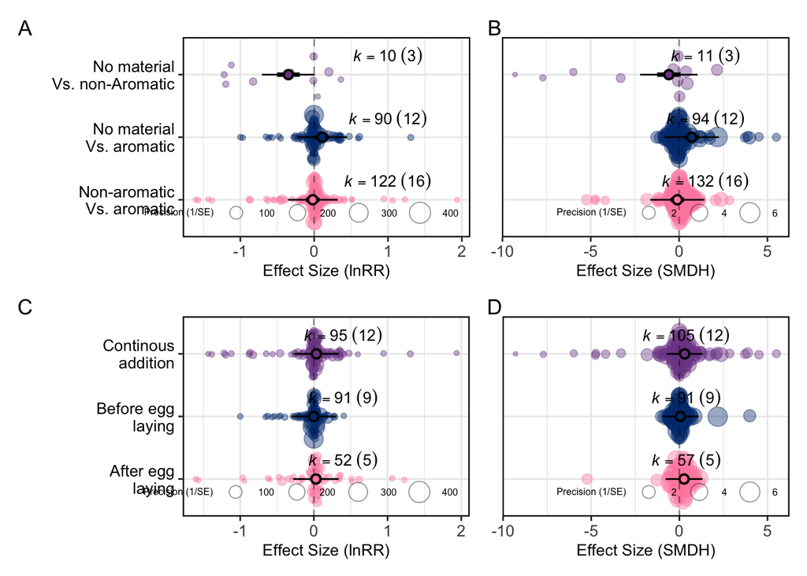

```r
## I am going to remove the y ticks from the SMDH plots to make it smaller..
SMDH_design_plot <- SMDH_design_plot +
  theme(axis.text.y  = element_blank(),
        axis.title.y = element_blank(),
        axis.ticks.y = element_blank())

SMDH_time_gnm_addition_plot <- SMDH_time_gnm_addition_plot +
  theme(axis.text.y  = element_blank(),
        axis.title.y = element_blank(),
        axis.ticks.y = element_blank())

# Combine using patchwork
Figure_design_time_gnm_addition <-
  ((lnRR_design_plot + SMDH_design_plot) /
     (lnRR_time_gnm_addition_plot + SMDH_time_gnm_addition_plot)) +
  plot_annotation(tag_levels = "A")
print(Figure_design_time_gnm_addition)
```

```r
## save image file
ggsave(here::here("figures/Figure_design_time_gnm_addition.png"),
       plot = Figure_design_time_gnm_addition, height = 240, width = 250, units = "mm", dpi = 600)
```

- Now the cropped figures for the main manuscript

```r
## I am going to remove the y ticks from the SMDH plots to make it smaller..
SMDH_design_plot_cropped <- SMDH_design_plot_cropped +
  theme(axis.text.y  = element_blank(),
        axis.title.y = element_blank(),
        axis.ticks.y = element_blank())

SMDH_time_gnm_addition_plot_cropped <- SMDH_time_gnm_addition_plot_cropped +
  theme(axis.text.y  = element_blank(),
        axis.title.y = element_blank(),
        axis.ticks.y = element_blank())

# Combine using patchwork
Figure_design_time_gnm_addition_cropped <-
  ((lnRR_design_plot_cropped + SMDH_design_plot_cropped) /
     (lnRR_time_gnm_addition_plot_cropped + SMDH_time_gnm_addition_plot_cropped)) +
  plot_annotation(tag_levels = "A")
```

```r
## save image file
ggsave(here::here("figures/Figure_design_time_gnm_addition_cropped.png"),
       plot = Figure_design_time_gnm_addition_cropped, height = 240, width = 250, units = "mm",
       dpi = 600)
```

## B. Combined Plot

### Parasite Type

```r
# Loading models for SMDH and lnRR
lnRR_parasite <- readRDS(here::here("model/lnRR_parasite.rds"))
SMDH_parasite <- readRDS(here::here("model/SMDH_parasite.rds"))

lnRR_parasite_plot <- orchard_plot(mod_results(
  lnRR_parasite,
  mod = "parasite_type",
  group = "paper_ID"),
  trunk.size = 0.25,
  branch.size = 1,
  twig.size = 0.5,
  alpha = 0.2,
  xlab = "") +
  scale_colour_manual(values = c("#FF8CAE", "#003A7D")) +
  scale_fill_manual(values = c("#FF8CAE", "#003A7D")) +
  labs(x = "",
       y = "lnRR") +
  theme(panel.border = element_rect(colour = "black", fill = NA, linewidth = 0.8),
        legend.position = "none",
        # legend.position.inside = c(0.98, 0.05),
        # legend.justification = c(1, 0),
        # legend.direction = "horizontal",
        legend.title = element_text(size = 6),
        legend.text = element_text(size = 6),
        axis.title = element_text(size = 10),
        axis.text.x = element_text(size = 10),
        axis.text.y = element_text(size = 6,angle = 0, vjust = 0.5, hjust = 1))
SMDH_parasite_plot <- orchard_plot(mod_results(
  SMDH_parasite,
  mod = "parasite_type",
  group = "paper_ID"),
  trunk.size = 0.25,
  branch.size = 1,
  twig.size = 0.5,
  alpha = 0.2,
  xlab = "") +
  scale_colour_manual(values = c("#FF8CAE", "#003A7D")) +
  scale_fill_manual(values = c("#FF8CAE", "#003A7D")) +
  labs(x = "",
       y = "SMD(H)") +
  theme(panel.border = element_rect(colour = "black", fill = NA, linewidth = 0.8),
        legend.position = "none",
        # legend.position.inside = c(0.98, 0.05),
        # legend.justification = c(1, 0),
        # legend.direction = "horizontal",
        legend.title = element_text(size = 6),
        legend.text = element_text(size = 6),
        axis.title = element_text(size = 10),
        axis.text.x = element_text(size = 10),
        axis.text.y = element_text(size = 6,angle = 0, vjust = 0.5, hjust = 1))
```

### Bird Species

```r
# Loading models for SMDH and lnRR
lnRR_birds <- readRDS(here::here("model/lnRR_birds.rds"))
SMDH_birds <- readRDS(here::here("model/SMDH_birds.rds"))

lnRR_birds_plot <- orchard_plot(mod_results(
  lnRR_birds,
  mod = "bird_species",
  group = "paper_ID"),
  trunk.size = 0.25,
  branch.size = 1,
  twig.size = 0.5,
  alpha = 0.2,
  xlab = "") +
  scale_colour_manual(values =  c("#00B0BE","#FFB255",  "#FF8CAE",
                                  "#F47A00", "#98C127","#003A7D","#7E4794")) +
  scale_fill_manual(values =  c("#00B0BE","#FFB255",  "#FF8CAE",
                                "#F47A00", "#98C127","#003A7D","#7E4794")) +
  labs(x = "",
       y = "lnRR") +
  theme(panel.border = element_rect(colour = "black", fill = NA, linewidth = 0.8),
        legend.position = "none",
        # legend.position.inside = c(0.98, 0.05),
        # legend.justification = c(1, 0),
        # legend.direction = "horizontal",
        legend.title = element_text(size = 6),
        legend.text = element_text(size = 6),
        axis.title = element_text(size = 10),
        axis.text.x = element_text(size = 10),
        axis.text.y = element_text(size = 6,angle = 0, vjust = 0.5, hjust = 1))
SMDH_birds_plot <- orchard_plot(mod_results(
  SMDH_birds,
  mod = "bird_species",
  group = "paper_ID"),
  trunk.size = 0.25,
  branch.size = 1,
  twig.size = 0.5,
  alpha = 0.2,
  xlab = "") +
  scale_colour_manual(values =  c("#00B0BE","#FFB255",  "#FF8CAE",
                                  "#F47A00", "#98C127","#003A7D","#7E4794")) +
  scale_fill_manual(values =  c("#00B0BE","#FFB255",  "#FF8CAE",
                                "#F47A00", "#98C127","#003A7D","#7E4794")) +
  labs(x = "",
       y = "SMD(H)") +
  theme(
    panel.border = element_rect(colour = "black", fill = NA, linewidth = 0.8),
    legend.position = "none",
    # legend.position.inside = c(0.98, 0.05),
    # legend.justification = c(1, 0),
    # legend.direction = "horizontal",
    legend.title = element_text(size = 6),
    legend.text = element_text(size = 6),
    axis.title = element_text(size = 10),
    axis.text.x = element_text(size = 10),
    axis.text.y = element_text(size = 6,angle = 0, vjust = 0.5, hjust = 1))
```

### Trait studied

```r
# Loading models for SMDH and lnRR
lnRR_trait <- readRDS(here::here("model/lnRR_trait.rds"))
SMDH_trait <- readRDS(here::here("model/SMDH_trait.rds"))

lnRR_trait_plot <- orchard_plot(mod_results(
  lnRR_trait,
  mod = "trait_type",
  group = "paper_ID"),
  trunk.size = 0.25,
  branch.size = 1,
  twig.size = 0.5,
  alpha = 0.2,
  xlab = "") +
  scale_colour_manual(values =  c("#00B0BE","#FFB255",  "#FF8CAE",
                                  "#F47A00", "#98C127","#003A7D","#7E4794")) +
  scale_fill_manual(values =  c("#00B0BE","#FFB255",  "#FF8CAE",
                                "#F47A00", "#98C127","#003A7D","#7E4794")) +
  labs(x = "",
       y = "lnRR") +
  theme(
    panel.border = element_rect(colour = "black", fill = NA, linewidth = 0.8),
    legend.position = "none",
    # legend.position.inside = c(0.98, 0.05),
    # legend.justification = c(1, 0),
    # legend.direction = "horizontal",
    legend.title = element_text(size = 6),
    legend.text = element_text(size = 6),
    axis.title = element_text(size = 10),
    axis.text.x = element_text(size = 10),
    axis.text.y = element_text(size = 6,angle = 0, vjust = 0.5, hjust = 1)
  )
SMDH_trait_plot <-
  orchard_plot(mod_results(
    SMDH_trait,
    mod = "trait_type",
    group = "paper_ID"),
    trunk.size = 0.25,
    branch.size = 1,
    twig.size = 0.5,
    alpha = 0.2,
    xlab = "") +
  scale_colour_manual(values =  c("#00B0BE","#FFB255",  "#FF8CAE",
                                  "#F47A00", "#98C127","#003A7D","#7E4794")) +
  scale_fill_manual(values =  c("#00B0BE","#FFB255",  "#FF8CAE",
                                "#F47A00", "#98C127","#003A7D","#7E4794")) +
  labs(x = "",
       y = "SMD(H)") +
  theme(  panel.border = element_rect(colour = "black", fill = NA, linewidth = 0.8),
          legend.position = "none",
          # legend.position.inside = c(0.98, 0.05),
          # legend.justification = c(1, 0),
          # legend.direction = "horizontal",
          legend.title = element_text(size = 6),
          legend.text = element_text(size = 6),
          axis.title = element_text(size = 10),
          axis.text.x = element_text(size = 10),
          axis.text.y = element_text(size = 6, angle = 0, vjust = 0.5, hjust = 1))
```

### Now we combine these plot

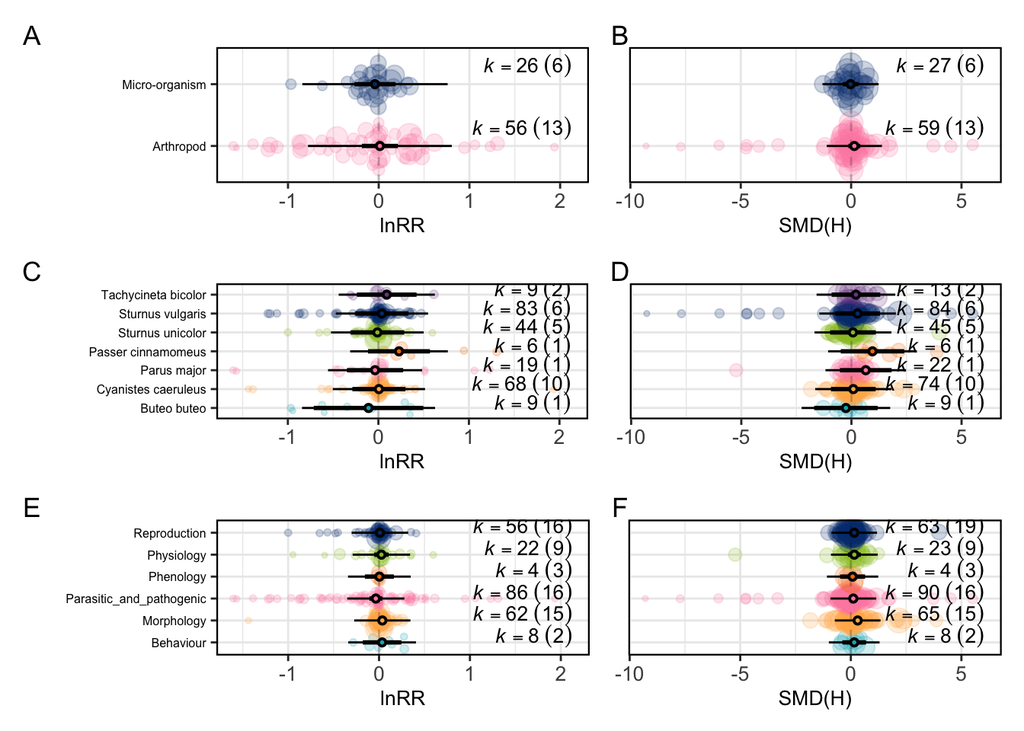

```r
## I am going to remove the y ticks from the SMDH plots to make it smaller..
SMDH_parasite_plot <- SMDH_parasite_plot +
  theme(axis.text.y  = element_blank(),
        axis.title.y = element_blank(),
        axis.ticks.y = element_blank())

SMDH_birds_plot <- SMDH_birds_plot +
  theme(axis.text.y  = element_blank(),
        axis.title.y = element_blank(),
        axis.ticks.y = element_blank())

SMDH_trait_plot <- SMDH_trait_plot +
  theme(axis.text.y  = element_blank(),
        axis.title.y = element_blank(),
        axis.ticks.y = element_blank())

# Combine using patchwork
Figure_parasite_birds_trait <-
  ((lnRR_parasite_plot + SMDH_parasite_plot) /
     (lnRR_birds_plot + SMDH_birds_plot) /
     (lnRR_trait_plot + SMDH_trait_plot)) +
  plot_annotation(tag_levels = "A")
print(Figure_parasite_birds_trait)
```

```r
## save image file
ggsave(here::here("figures/Figure_parasite_birds_trait.png"),
       plot = Figure_parasite_birds_trait, height = 250, width = 400, units = "mm", dpi = 600)
```

## Publication Bias Tests

```
## Ignoring unknown labels:
## • parse : "TRUE"
## Ignoring unknown labels:
## • parse : "TRUE"
## Ignoring unknown labels:
## • parse : "TRUE"
## Ignoring unknown labels:
## • parse : "TRUE"
```

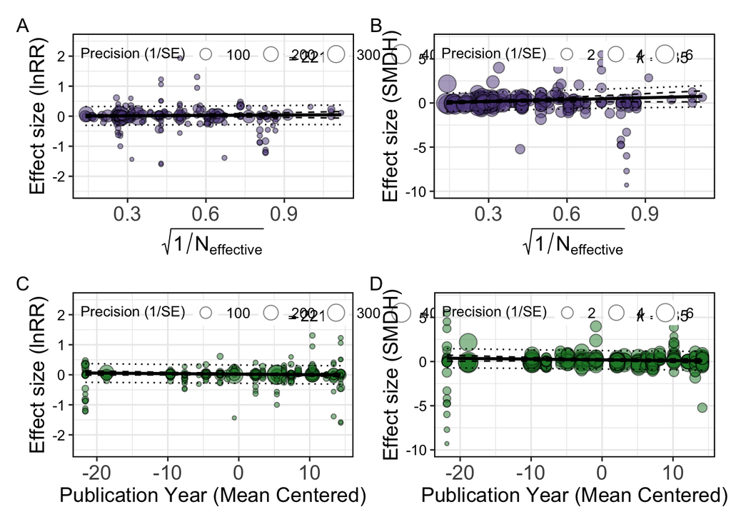

```r
###---Small study Effects ----###
lnRR_small_study <- readRDS(here::here("model/lnRR_small_study.rds"))
SMDH_small_study <- readRDS(here::here("model/SMDH_small_study.rds"))


lnRR_small_study_bubble <- orchaRd::bubble_plot(mod_results(
  lnRR_small_study,
  mod = "sqrt_effective_n_inv",
  group = "paper_ID",
  weights = "prop"),
  group = "paper_ID") +
  scale_colour_manual(values = "mediumpurple4") +
  scale_fill_manual(values = "mediumpurple4") +
  coord_cartesian(ylim = c(-2.5, 2.5)) +
  labs(y = "Effect size (lnRR)",
       x = expression(sqrt(1 / N[effective]))) +
  theme(panel.border = element_rect(colour = "black", fill = NA, linewidth = 0.8),
        legend.title = element_text(size = 10),
        legend.text = element_text(size = 10),
        axis.title = element_text(size = 14),
        axis.text.x = element_text(size = 14),
        axis.text.y = element_text(angle = 0, vjust = 0.5, hjust = 1))
SMDH_small_study_bubble <- orchaRd::bubble_plot(mod_results(
  SMDH_small_study,
  mod = "sqrt_effective_n_inv",
  group = "paper_ID",
  weights = "prop"),
  group = "paper_ID") +
  scale_colour_manual(values = "mediumpurple4") +
  scale_fill_manual(values = "mediumpurple4") +
  coord_cartesian(ylim = c(-10, 7)) +
  labs(y = "Effect size (SMDH)",
       x = expression(sqrt(1 / N[effective]))) +
  theme(panel.border = element_rect(colour = "black", fill = NA, linewidth = 0.8),
        legend.title = element_text(size = 10),
        legend.text = element_text(size = 10),
        axis.title = element_text(size = 14),
        axis.text.x = element_text(size = 14),
        axis.text.y = element_text(angle = 0, vjust = 0.5, hjust = 1))
###---Decline Effects ----###

lnRR_decline_eff <- readRDS(here::here("model/lnRR_decline_eff.rds"))
SMDH_decline_eff <- readRDS(here::here("model/SMDH_decline_eff.rds"))


lnRR_decline_eff_bubble <- orchaRd::bubble_plot(mod_results(
  lnRR_decline_eff,
  mod = "year_MeanCenter",
  group = "paper_ID",
  weights = "prop"),
  group = "paper_ID") +
  scale_colour_manual(values = "#218833") +
  scale_fill_manual(values = "#218833") +
  coord_cartesian(ylim = c(-2.5, 2.5)) +
  labs(y = "Effect size (lnRR)",
       x = "Publication Year (Mean Centered)") +
  theme(panel.border = element_rect(colour = "black", fill = NA, linewidth = 0.8),
        legend.title = element_text(size = 10),
        legend.text = element_text(size = 10),
        axis.title = element_text(size = 14),
        axis.text.x = element_text(size = 14),
        axis.text.y = element_text(angle = 0, vjust = 0.5, hjust = 1))
SMDH_decline_effect_bubble <- orchaRd::bubble_plot(mod_results(
  SMDH_decline_eff,
  mod = "year_MeanCenter",
  group = "paper_ID",
  weights = "prop"),
  group = "paper_ID") +
  scale_colour_manual(values = "#218833") +
  scale_fill_manual(values = "#218833") +
  coord_cartesian(ylim = c(-10, 7)) +
  labs(y = "Effect size (SMDH)",
       x = "Publication Year (Mean Centered)") +
  theme(panel.border = element_rect(colour = "black", fill = NA, linewidth = 0.8),
        legend.title = element_text(size = 10),
        legend.text = element_text(size = 10),
        axis.title = element_text(size = 14),
        axis.text.x = element_text(size = 14),
        axis.text.y = element_text(angle = 0, vjust = 0.5, hjust = 1))
# Combine using patchwork
Figure_publication_bias <-
  ((lnRR_small_study_bubble + SMDH_small_study_bubble) /
     (lnRR_decline_eff_bubble + SMDH_decline_effect_bubble)) +
  plot_annotation(tag_levels = "A")
print(Figure_publication_bias)
```

```r
## save image file
ggsave(here::here("figures/Figure_publication_bias.png"),
       plot = Figure_publication_bias, height = 300, width = 400, units = "mm", dpi = 600)
```

# Supplementary Material Table

```r
merged_data_extraction <- read_csv(here::here("data/03_data_cleaning/merged_data_extraction.csv"),
                                   show_col_types = F)

dataset_analysis <- read_csv(here::here("data/04_data_analysis/dataset_analysis.csv"),
                             show_col_types = F)

excluded_proxies <- merged_data_extraction %>%
  filter(fulltext_screening == "included") %>%
  filter(proxy_decision == "exclude") %>%
  select(paper_ID, fitness_proxy, proxy_comment) %>%
  distinct() %>%
  group_by(paper_ID) %>%
  summarise(
    `Number of proxies` = n(),
    `Excluded Proxies` = paste(fitness_proxy, collapse = ", "),
    `Reason for Exclusion` = paste(proxy_comment,  collapse = "; "),
    .groups = "drop")

SA_only_proxies <- dataset_analysis %>%
  filter(proxy_decision == "sensitivity-analysis") %>%
  select(paper_ID, fitness_proxy, proxy_comment) %>%
  distinct() %>%
  group_by(paper_ID) %>%
  summarise(
    `Number of proxies` = n(),
    `Excluded Proxies` = paste(fitness_proxy, collapse = ", "),
    `Reason for Exclusion` = paste(proxy_comment,  collapse = "; "),
    .groups = "drop")



# Now binding them together
combined_summary <- bind_rows(
  excluded_proxies %>% mutate(Category = "Completely excluded"),
  SA_only_proxies   %>% mutate(Category = "Sensitivity-analysis only")) %>%
  arrange(Category, paper_ID)

# Group by category
excluded_proxies <- combined_summary %>%
  gt() %>%
  tab_header(
    title = md("**Excluded Fitness Proxies**")) %>%
  # define row-groups
  tab_row_group(
    group    = "Completely excluded",
    rows     = Category == "Completely excluded") %>%
  tab_row_group(
    group    = "Sensitivity-analysis only",
    rows     = Category == "Sensitivity-analysis only") %>%
  # hide the helper column
  cols_hide("Category") %>%
  # relabel columns
  cols_label(
    `paper_ID`             = "Paper ID",
    `Number of proxies`    = "Number\nof Proxies",
    `Excluded Proxies`     = "Excluded\nProxies",
    `Reason for Exclusion` = "Reason for Exclusion") %>%
  fmt_markdown(columns = c(`Excluded Proxies`, `Reason for Exclusion`)) %>%
  opt_align_table_header(align = "left") %>%
  cols_align(align   = "left",
             columns = everything()) %>%
  tab_options(
    table.width               = pct(90),
    row.striping.background_color = "#F7F7F7")
print(excluded_proxies)
```

[output not shown]

[output cut: 473 more lines]

[output not shown]

```r
## save image file
gtsave(data = excluded_proxies,
       filename = here::here("/tables/excluded_proxies_table.pdf"),
       expand = 10)   # adds a little padding around the table
```

## Table: Sensitivity analysis for intercept only model

```r
# Loading the models including only published data
SA_lnRR_published <- readRDS(here::here("model/sensitivity_analysis/SA_lnRR_published.rds"))
SA_SMDH_published <- readRDS(here::here("model/sensitivity_analysis/SA_SMDH_published.rds"))

# Loading the models without Comparison Type 3
SA_lnRR_no_comp3 <- readRDS(here::here("model/sensitivity_analysis/SA_lnRR_no_comp3.rds"))
SA_SMDH_no_comp3 <- readRDS(here::here("model/sensitivity_analysis/SA_SMDH_no_comp3.rds"))

# Loading the models including flagged proxies
SA_lnRR_flagged <- readRDS(here::here("model/sensitivity_analysis/SA_lnRR_flagged.rds"))
SA_SMDH_flagged <- readRDS(here::here("model/sensitivity_analysis/SA_SMDH_flagged.rds"))

# Loading the models without data for those using 0 as ES because authors reported no effect
SA_lnRR_no_missingES <- readRDS(here::here("model/sensitivity_analysis/SA_lnRR_no_missingES.rds"))
SA_SMDH_no_missingES <- readRDS(here::here("model/sensitivity_analysis/SA_SMDH_no_missingES.rds"))

# Loading the models without data for those using 0 as ES because authors reported no effect and including flagged proxies
SA_lnRR_flagged_no_missingES <-
  readRDS(here::here("model/sensitivity_analysis/SA_lnRR_flagged_no_missingES.rds"))
SA_SMDH_flagged_no_missingES <- readRDS(here::here("model/sensitivity_analysis/SA_SMDH_flagged_no_missingES.rds"))

# Loading the model for SMDH without inferential statistics. There is none for lnRR because we can only uses means and deviation to estimate lnRR
SA_SMDH_no_inferential <- readRDS(here::here("model/sensitivity_analysis/SA_SMDH_no_inferential.rds"))

# Loading the model for Geary's Test Passed. There is none for SMDH because we do not know the guideline for SMDH and Geary's Test
SA_lnRR_geary_passed <- readRDS(here::here("model/sensitivity_analysis/SA_lnRR_geary_passed.rds"))

# Now let's build the table
SA_intercept_only <- tibble::tibble(
  effect_size = c("lnRR","lnRR","lnRR","lnRR","lnRR","lnRR",
                  "SMD(H)","SMD(H)","SMD(H)","SMD(H)","SMD(H)","SMDH"),
  data_used = c(
    "Including published data only",
    "Excluding Experimental Design Non-Aromatic Vs. No added material",
    "Including flagged proxies",
    "Without those cases where author reported no effect of the treatment",
    "Including flagged proxies and without the cases with no effect of the treatment",
    "Excluding effect sizes where lnRR failed Geary's Test",
    "Including published data only",
    "Excluding Experimental Design Non-Aromatic Vs. No added material",
    "Including flagged proxies",
    "Without those cases where author reported no effect of the treatment",
    "Including flagged proxies and without the cases with no effect of the treatment",
    "Without the cases where SMDH was calculated from inferential statistics"),

  Estimate = c(SA_lnRR_published$b[1],
               SA_lnRR_no_comp3$b[1],
               SA_lnRR_flagged$b[1],
               SA_lnRR_no_missingES$b[1],
               SA_lnRR_flagged_no_missingES$b[1],
               SA_lnRR_geary_passed$b[1],
               SA_SMDH_published$b[1],
               SA_SMDH_no_comp3$b[1],
               SA_SMDH_flagged$b[1],
               SA_SMDH_no_missingES$b[1],
               SA_SMDH_flagged_no_missingES$b[1],
               SA_SMDH_no_inferential$b[1]),

  CI_Lower = c(SA_lnRR_published$ci.lb,
               SA_lnRR_no_comp3$ci.lb,
               SA_lnRR_flagged$ci.lb,
               SA_lnRR_no_missingES$ci.lb,
               SA_lnRR_flagged_no_missingES$ci.lb,
               SA_lnRR_geary_passed$ci.lb,
               SA_SMDH_published$ci.lb,
               SA_SMDH_no_comp3$ci.lb,
               SA_SMDH_flagged$ci.lb,
               SA_SMDH_no_missingES$ci.lb,
               SA_SMDH_flagged_no_missingES$ci.lb,
               SA_SMDH_no_inferential$ci.lb),

  CI_Upper = c(SA_lnRR_published$ci.ub,
               SA_lnRR_no_comp3$ci.ub,
               SA_lnRR_flagged$ci.ub,
               SA_lnRR_no_missingES$ci.ub,
               SA_lnRR_flagged_no_missingES$ci.ub,
               SA_lnRR_geary_passed$ci.ub,
               SA_SMDH_published$ci.ub,
               SA_SMDH_no_comp3$ci.ub,
               SA_SMDH_flagged$ci.ub,
               SA_SMDH_no_missingES$ci.ub,
               SA_SMDH_flagged_no_missingES$ci.ub,
               SA_SMDH_no_inferential$ci.ub),

  PI_Lower = c(predict(SA_lnRR_published)$pi.lb,
               predict(SA_lnRR_no_comp3)$pi.lb,
               predict(SA_lnRR_flagged)$pi.lb,
               predict(SA_lnRR_no_missingES)$pi.lb,
               predict(SA_lnRR_flagged_no_missingES)$pi.lb,
               predict(SA_lnRR_geary_passed)$pi.lb,
               predict(SA_SMDH_published)$pi.lb,
               predict(SA_SMDH_no_comp3)$pi.lb,
               predict(SA_SMDH_flagged)$pi.lb,
               predict(SA_SMDH_no_missingES)$pi.lb,
               predict(SA_SMDH_flagged_no_missingES)$pi.lb,
               predict(SA_SMDH_no_inferential)$pi.lb),

  PI_Upper = c(predict(SA_lnRR_published)$pi.ub,
               predict(SA_lnRR_no_comp3)$pi.ub,
               predict(SA_lnRR_flagged)$pi.ub,
               predict(SA_lnRR_no_missingES)$pi.ub,
               predict(SA_lnRR_flagged_no_missingES)$pi.ub,
               predict(SA_lnRR_geary_passed)$pi.ub,
               predict(SA_SMDH_published)$pi.ub,
               predict(SA_SMDH_no_comp3)$pi.ub,
               predict(SA_SMDH_flagged)$pi.ub,
               predict(SA_SMDH_no_missingES)$pi.ub,
               predict(SA_SMDH_flagged_no_missingES)$pi.ub,
               predict(SA_SMDH_no_inferential)$pi.ub),

  P_value =  c(SA_lnRR_published$pval,
               SA_lnRR_no_comp3$pval,
               SA_lnRR_flagged$pval,
               SA_lnRR_no_missingES$pval,
               SA_lnRR_flagged_no_missingES$pval,
               SA_lnRR_geary_passed$pval,
               SA_SMDH_published$pval,
               SA_SMDH_no_comp3$pval,
               SA_SMDH_flagged$pval,
               SA_SMDH_no_missingES$pval,
               SA_SMDH_flagged_no_missingES$pval,
               SA_SMDH_no_inferential$pval),

  Q_value = c(SA_lnRR_published$QE,
              SA_lnRR_no_comp3$QE,
              SA_lnRR_flagged$QE,
              SA_lnRR_no_missingES$QE,
              SA_lnRR_flagged_no_missingES$QE,
              SA_lnRR_geary_passed$QE,
              SA_SMDH_published$QE,
              SA_SMDH_no_comp3$QE,
              SA_SMDH_flagged$QE,
              SA_SMDH_no_missingES$QE,
              SA_SMDH_flagged_no_missingES$QE,
              SA_SMDH_no_inferential$QE),

  k_effect_sizes = c(SA_lnRR_published$k,
                     SA_lnRR_no_comp3$k,
                     SA_lnRR_flagged$k,
                     SA_lnRR_no_missingES$k,
                     SA_lnRR_flagged_no_missingES$k,
                     SA_lnRR_geary_passed$k,
                     SA_SMDH_published$k,
                     SA_SMDH_no_comp3$k,
                     SA_SMDH_flagged$k,
                     SA_SMDH_no_missingES$k,
                     SA_SMDH_flagged_no_missingES$k,
                     SA_SMDH_no_inferential$k),

  n_studies = c(length(SA_lnRR_published$s.levels.f[[1]]),
                length(SA_lnRR_no_comp3$s.levels.f[[1]]),
                length(SA_lnRR_flagged$s.levels.f[[1]]),
                length(SA_lnRR_no_missingES$s.levels.f[[1]]),
                length(SA_lnRR_flagged_no_missingES$s.levels.f[[1]]),
                length(SA_lnRR_geary_passed$s.levels.f[[1]]),
                length(SA_SMDH_published$s.levels.f[[1]]),
                length(SA_SMDH_no_comp3$s.levels.f[[1]]),
                length(SA_SMDH_flagged$s.levels.f[[1]]),
                length(SA_SMDH_no_missingES$s.levels.f[[1]]),
                length(SA_SMDH_flagged_no_missingES$s.levels.f[[1]]),
                length(SA_SMDH_no_inferential$s.levels.f[[1]])))


# Combine CI and PI into a single column each for compactness
SA_intercept_only <- SA_intercept_only %>%
  mutate(
    CI = paste0("[", sprintf("%.3f", CI_Lower), ", ", sprintf("%.3f", CI_Upper), "]"),
    PI = paste0("[", sprintf("%.3f", PI_Lower), ", ", sprintf("%.3f", PI_Upper), "]"),
    P_value = scales::pvalue(P_value),
    Q_value = sprintf("%.2f", Q_value)
  ) %>%
  select(
    effect_size,
    data_used,
    Estimate,
    CI,
    PI,
    P_value,
    k_effect_sizes,
    n_studies)

# Let's make this table pretty
SA_intercept_only <- SA_intercept_only %>%
  gt() %>%
  tab_options(
    table.font.size = px(12),
    table.border.top.color = "black",
    table.border.bottom.color = "black",
    heading.title.font.size = px(14),
    heading.subtitle.font.size = px(12),
    column_labels.font.weight = "bold"
  ) %>%
  tab_header(
    title = md("**Summary of Sensitivity Analyses for lnRR and SMD(H) Intercept-only models**")) %>%
  cols_label(
    effect_size = "Effect Size",
    data_used = "Data used in model",
    Estimate = "Estimate",
    CI = "95% CI",
    PI = "95% PI",
    P_value = "P-value",
    k_effect_sizes = "k (No. of Effect Sizes)",
    n_studies = "n (No. of Studies)"
  ) %>%
  fmt_number(
    columns = c(Estimate),
    decimals = 3
  ) %>%
  tab_style(
    style = cell_borders(
      sides = "bottom",
      color = "black",
      weight = px(1)
    ),
    locations = cells_body()
  ) %>%
  tab_options(
    table.font.size = "small",
    heading.title.font.size = 14,
    table.border.top.width = px(2),
    column_labels.font.weight = "bold",
    row_group.font.weight = "bold"
  ) %>%
  opt_table_outline()
```

```r
## Saving as an image
gtsave(SA_intercept_only, here::here("tables/SA_intercept_only.png"))

## For saving as a docx file
gtsave(SA_intercept_only, here::here("tables/SA_intercept_only.docx"))
gtsave(SA_intercept_only, here::here("tables/SA_intercept_only.html"))
```

```r
# Sun Aug 31 20:11:12 2025 ------------------------------
# Make code execuatable, but eval = FALSE
t4 <- data.frame(
  rho  = rho_range,
  "overall effect"  = sapply(lnRR_VCV_range, function(x) coef(x)),
  "standard error" = sapply(lnRR_VCV_range, function(x) x$se),
  "p-value" = sapply(lnRR_VCV_range, function(x) x$pval),
  "Lower CI" = sapply(lnRR_VCV_range, function(x) x$ci.lb),
  "Upper CI" = sapply(lnRR_VCV_range, function(x) x$ci.ub),
  "Log-likehood" = sapply(lnRR_VCV_range, function(x) fitstats(x)[1,1]),
  "AIC" = sapply(lnRR_VCV_range, function(x) fitstats(x)[3,1]),
  "BIC" = sapply(lnRR_VCV_range, function(x) fitstats(x)[4,1]),
  "AICc" = sapply(lnRR_VCV_range, function(x) fitstats(x)[5,1]))

colnames(t4) <- c("Sampling correlation", "Overall effect (lnRR)",
                  "Standard error", "p-value", "Lower CI",
                  "Upper CI", "Log-likehood", "AIC", "BIC", "AICc")

t4 %>% dfround(4) %>%
  DT::datatable()
```

## Table: RoB Meta-regressions

```r
# Loading models for blinding performed or not
lnRR_blinding <- readRDS(here::here("model/lnRR_blinding.rds"))
SMDH_blinding <- readRDS(here::here("model/SMDH_blinding.rds"))

# Loading models for random sampling assignment performed or not
lnRR_random_assignment <- readRDS(here::here("model/lnRR_random_assignment.rds"))
SMDH_random_assignment <- readRDS(here::here("model/SMDH_random_assignment.rds"))

# Loading models for missing data present or not
lnRR_missing_data <- readRDS(here::here("model/lnRR_missing_data.rds"))
SMDH_missing_data <- readRDS(here::here("model/SMDH_missing_data.rds"))
```

```r
# Let's source our custom function to extract values from the meta-regressions
source(here::here("functions/extractor_metareg.R"))

## For lnRR Values
lnRR_results_RoB <- extractor_metareg(lnRR_blinding,"blinding") %>%
  bind_rows(extractor_metareg(lnRR_random_assignment,"random_assignment")) %>%
  bind_rows(extractor_metareg(lnRR_missing_data,"missing_data")) %>%
  mutate(effect_size = "lnRR")

## For SMDH Values
SMDH_results_RoB <- extractor_metareg(SMDH_blinding,"blinding") %>%
  bind_rows(extractor_metareg(SMDH_random_assignment,"random_assignment")) %>%
  bind_rows(extractor_metareg(SMDH_missing_data,"missing_data")) %>%
  mutate(effect_size = "SMDH")

## Now let's write the table for publication:
# Combine both results
combined_results_RoB <- bind_rows(lnRR_results_RoB, SMDH_results_RoB) %>%
  pivot_wider(
    id_cols = c(moderator, level),
    names_from = effect_size,
    values_from = c(estimate, p_value, CI, PI, k, n),
    names_glue = "{.value}_{effect_size}"
  ) %>% # Prepare row labels to mimic grouping
  arrange(moderator, level) %>%
  mutate(row_type = "level")

# Final combined table with headers and levels
combined_results_RoB <- combined_results_RoB %>%
  # bind_rows(moderator_header ,combined_results) %>%
  arrange(moderator, row_type) %>% select(-row_type) %>%
  relocate(level, .after = moderator) %>%
  mutate(moderator = case_when(
    moderator == "blinding" ~ "1. Blinding",
    moderator == "random_assignment" ~ "2. Random assignment to treatment",
    moderator == "missing_data" ~ "3. Partial Reporting"
  )) %>%
  mutate(moderator = factor(
    moderator,
    levels = c(
      "1. Blinding",
      "2. Random assignment to treatment",
      "3. Partial Reporting"
    ))) %>%
  arrange(moderator) %>%
  mutate(level = case_when(
    level == "y" ~ "Yes",
    level == "n" ~ "No",
    .default = level))

# Clean up or reorder columns for display
# Select and order columns for clarity
RoB_table <- combined_results_RoB %>%
  gt(groupname_col = "moderator") %>%
  tab_header(title = md("**Multilevel Meta Regressions for Risk of Bias**")) %>%
  cols_label(
    # R2_marginal_lnRR = "R²_mar",
    # R2_marginal_SMDH = "R²_mar",
    level = "Level",
    estimate_lnRR = "Estimate",
    CI_lnRR = "95% CI",
    PI_lnRR = "95% PI",
    p_value_lnRR = "P-val",
    k_lnRR = "k",
    n_lnRR = "n",
    estimate_SMDH = "Estimate",
    CI_SMDH = "95% CI",
    PI_SMDH = "95% PI",
    p_value_SMDH = "P-val",
    k_SMDH = "k",
    n_SMDH = "n") %>%
  sub_missing(
    columns = everything(),
    missing_text = "") %>%
  opt_table_outline() %>%
  tab_options(
    table.font.size = "small",
    heading.title.font.size = 12,
    table.border.top.width = px(2),
    column_labels.font.weight = "medium",
    row_group.font.weight = "bold") %>%
  tab_style(
    style = cell_borders(
      sides = "bottom",
      color = "black",
      weight = px(1)),
    locations = cells_body()) %>%
  tab_style(
    style = cell_text(weight = "bold"),
    locations = cells_body(
      columns = c(p_value_lnRR),
      rows = p_value_lnRR < 0.05)) %>%
  tab_style(
    style = cell_text(weight = "bold"),
    locations = cells_body(
      columns = c(p_value_SMDH),
      rows = p_value_SMDH < 0.05)) %>%
  tab_spanner(label = "lnRR", columns = contains("_lnRR")) %>%
  tab_spanner(label = "SMDH", columns = contains("_SMDH"))  %>%
  tab_style(
    style = cell_text(whitespace = "nowrap"),
    locations = cells_body(columns = c(CI_lnRR, PI_lnRR, CI_SMDH, PI_SMDH)))
```

```r
# saving the image
gtsave(RoB_table,here::here("tables/SA_RoB_table.png"))

# saving as a docx file or html
gtsave(RoB_table,here::here("tables/SA_RoB_table.docx"))
gtsave(RoB_table,here::here("tables/SA_RoB_table.html"))
```

# TABLES

## Table: Output from meta-regressions

```r
# Loading models for experimental design
lnRR_design <- readRDS(here::here("model/lnRR_design.rds"))
SMDH_design <- readRDS(here::here("model/SMDH_design.rds"))

# Loading models for parasite type
lnRR_parasite <- readRDS(here::here("model/lnRR_parasite.rds"))
SMDH_parasite <- readRDS(here::here("model/SMDH_parasite.rds"))

# Loading models for time of green nest material addition
lnRR_time_gnm_addition <- readRDS(here::here("model/lnRR_time_gnm_addition.rds"))
SMDH_time_gnm_addition <- readRDS(here::here("model/SMDH_time_gnm_addition.rds"))

# Loading models for the type of trait studied
lnRR_trait <- readRDS(here::here("model/lnRR_trait.rds"))
SMDH_trait <- readRDS(here::here("model/SMDH_trait.rds"))

# Loading models for the bird species studied
lnRR_birds <- readRDS(here::here("model/lnRR_birds.rds"))
SMDH_birds <- readRDS(here::here("model/SMDH_birds.rds"))
```

```r
# Let's source our custom function to extract values from the meta-regressions
source(here::here("functions/extractor_metareg.R"))

## For lnRR Values
lnRR_results <- extractor_metareg(lnRR_parasite,"parasite_type") %>%
  bind_rows(extractor_metareg(lnRR_birds,"bird_species")) %>%
  bind_rows(extractor_metareg(lnRR_trait,"trait_type")) %>%
  bind_rows(extractor_metareg(lnRR_design,"comparision_type")) %>%
  bind_rows(extractor_metareg(lnRR_time_gnm_addition,"time_of_gnm_addition")) %>%
  mutate(effect_size = "lnRR")

## For SMDH Values
SMDH_results <- extractor_metareg(SMDH_parasite,"parasite_type") %>%
  bind_rows(extractor_metareg(SMDH_birds,"bird_species")) %>%
  bind_rows(extractor_metareg(SMDH_trait,"trait_type")) %>%
  bind_rows(extractor_metareg(SMDH_design,"comparision_type")) %>%
  bind_rows(extractor_metareg(SMDH_time_gnm_addition,"time_of_gnm_addition")) %>%
  mutate(effect_size = "SMDH")

## Now let's write the table for publication:
# Combine both results
combined_results <- bind_rows(lnRR_results, SMDH_results) %>%
  pivot_wider(
    id_cols = c(moderator, level),
    names_from = effect_size,
    values_from = c(estimate, p_value, CI, PI, k, n),
    names_glue = "{.value}_{effect_size}"
  ) %>% # Prepare row labels to mimic grouping
  arrange(moderator, level) %>%
  mutate(row_type = "level")

# # Create moderator header rows for heterogeneity metrics
#   moderator_header<-bind_rows(lnRR_results, SMDH_results) %>%
#   select(moderator, effect_size, R2_marginal) %>%
#     distinct() %>%
#     pivot_wider(
#       names_from = effect_size,
#       values_from = c( R2_marginal),
#       names_glue = "{.value}_{effect_size}"
#     ) %>%
#   mutate(level = "Heterogeneity ",
#          row_type = "moderator")

# Final combined table with headers and levels
combined_results <- combined_results %>%
  # bind_rows(moderator_header ,combined_results) %>%
  arrange(moderator, row_type) %>% select(-row_type) %>%
  relocate(level, .after = moderator) %>%
  mutate(moderator = case_when(
    moderator == "parasite_type" ~ "5. Parasite\nType",
    moderator == "bird_species" ~ "3. Bird\nSpecies",
    moderator == "trait_type" ~ "4. Trait\nCategory",
    moderator == "comparision_type" ~ "1. Experimental\nDesign",
    moderator == "time_of_gnm_addition" ~ "2. Time of\nGNM Addition"
  )) %>%
  mutate(moderator = factor(
    moderator,
    levels = c(
      "1. Experimental\nDesign",
      "2. Time of\nGNM Addition",
      "3. Bird\nSpecies",
      "4. Trait\nCategory",
      "5. Parasite\nType"
    ))) %>%
  arrange(moderator) %>%
  mutate(level = case_when(
    level==1 ~ "Non-aromatic\nvs. Aromatic",
    level==2 ~ "No added material\nvs. Aromatic",
    level==3 ~ "No added material\nvs. Non-aromatic",
    level=="a" ~ "After egg\nhatching",
    level=="b" ~ "Before egg\nhatching",
    level=="c" ~ "Continously through\nnesting phase",
    level=="Parasitic_and_pathogenic"~"Parasitic and\nPathogen Related",
    .default = level))


# Optional: clean up or reorder columns for display
# Select and order columns for clarity
MLMR_table <- combined_results %>%
  gt(groupname_col = "moderator") %>%
  tab_header(title = md("**Multilevel Meta Regressions for Exploratory Analyses**")) %>%
  cols_label(
    # R2_marginal_lnRR = "R²_mar",
    # R2_marginal_SMDH = "R²_mar",
    level = "Level",
    estimate_lnRR = "Estimate",
    CI_lnRR = "95% CI",
    PI_lnRR = "95% PI",
    p_value_lnRR = "P-val",
    k_lnRR = "k",
    n_lnRR = "n",
    estimate_SMDH = "Estimate",
    CI_SMDH = "95% CI",
    PI_SMDH = "95% PI",
    p_value_SMDH = "P-val",
    k_SMDH = "k",
    n_SMDH = "n") %>%
  sub_missing(
    columns = everything(),
    missing_text = "") %>%
  opt_table_outline() %>%
  tab_options(
    table.font.size = "small",
    heading.title.font.size = 12,
    table.border.top.width = px(2),
    column_labels.font.weight = "medium",
    row_group.font.weight = "bold"
  ) %>%
  tab_style(
    style = cell_borders(
      sides = "bottom",
      color = "black",
      weight = px(1)),
    locations = cells_body()) %>%
  # tab_style(
  #   style = cell_text(weight = "bold"),
  #   locations = cells_body(
  #     rows = level == "Heterogeneity"
  #   )) %>%
  tab_style(
    style = cell_text(weight = "bold"),
    locations = cells_body(
      columns = c(p_value_lnRR),
      rows = p_value_lnRR < 0.05)) %>%
  tab_style(
    style = cell_text(weight = "bold"),
    locations = cells_body(
      columns = c(p_value_SMDH),
      rows = p_value_SMDH < 0.05)) %>%
  tab_spanner(label = "lnRR", columns = contains("_lnRR")) %>%
  tab_spanner(label = "SMDH", columns = contains("_SMDH"))  %>%
  tab_style(
    style = cell_text(whitespace = "nowrap"),
    locations = cells_body(columns = c(CI_lnRR, PI_lnRR, CI_SMDH, PI_SMDH)))
```

```r
## saving the image
gtsave(MLMR_table, here::here("tables/MLMR_table.png"))
## saving as a docx file or html
gtsave(MLMR_table,here::here("tables/MLMR_table.docx"))
gtsave(MLMR_table,here::here("tables/MLMR_table.html"))
```